# Team 9 - Project Proposal

**Visualizing World’s Biggest Data Breaches and Hacks Over Time**

Authors

1. Heng Yu Xin
2. Javier Si Zhao Hong
3. Tan Guan Hong
4. Hong Ziyang
5. Abdul Haliq Bin Abdul Rahim
6. See Toh Ming Xuan Axel

For this document, the following libraries are required:

```r
library(conflicted)
library(tidyverse)
library(knitr)
```

# 1 Introduction

## 1.1 Background and Significance

The surge in digital data transmission has amplified the susceptibility of information systems to security breaches. Our project utilizes the dataset from **Information is Beautiful** (David McCandless 2024) on the world’s biggest data breaches to augment the existing visualization.

The dataset provides awareness of the scale and impact of data breaches across various sectors and organizations and highlights the importance of data security for businesses and individuals.

## 1.2 Objectives

We plan to add features to the visualization, normalize the data and run comparative analyses, and develop models to predict future breaches. Our objective is to transform this visualization into a more dynamic and analytical tool that not only reflects previous data breaches but also provides insights into potential future trends.

## 1.3 Data Source

The dataset is obtained from **Information is Beautiful** (David McCandless 2024), which contains information on the world’s biggest data breaches. The dataset includes the date of the breach, the organization involved, the method of the breach, the number of records lost, the sector of the organization and more.

# 2 Original Visualization Assessment

## 2.1 Description of the Visualization

The original visualization, shown in Figure 1, is a compelling graphical representation that uses varying bubble sizes and colours to depict the magnitude and frequency of major data breaches impacting organizations worldwide. Each bubble represents a data breach event, with the size corresponding to the number of records lost and the colour indicating whether the event has an interesting story. Organized chronologically and segmented by year, the visualization offers a clear timeline of data breaches, providing immediate visual insight into the evolution and escalation of data security issues over time.

In addition, its interactive elements allow users to filter breaches by sector and method, enabling a more customized exploration of the data. The display further supports in-depth exploration of each incident, presenting details like the impacted organization, total records compromised, and direct links to related articles.

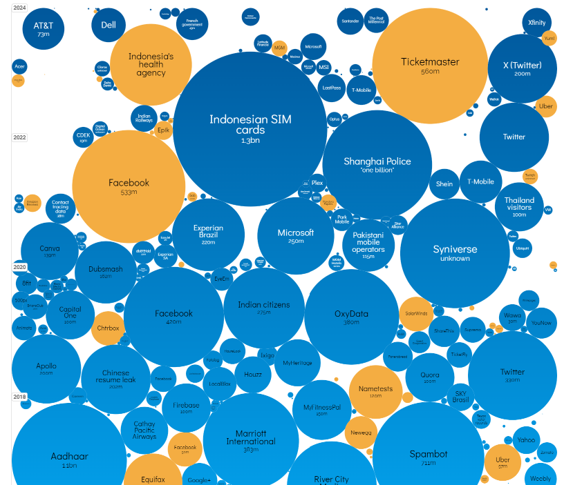

Figure 1: This bubble chart illustrates the scale and impact of major global data breaches, categorized by the organization and number of records lost. (David McCandless 2024)

## 2.2 Critical Assessment

The original visualization excels in several areas but also presents certain limitations that could be addressed to enhance its utility and interpretability:

**Strengths**

- **Visual Impact:** The use of large, coloured bubbles immediately draws attention and effectively communicates the relative scale of data breaches. The varying bubble sizes enable quick visual comparisons between the magnitudes of different breaches, helping to identify which incidents had the largest impact.
- **Interactivity:** Interactive elements allow users to filter breaches by sector and type, facilitating a customized exploration of the data.
- **Information Density:** A significant amount of information is compactly displayed, providing quick insights into data breaches across different organisations and record lost.
- **Chronological Clarity:** The layout organizes data breaches chronologically, making it easy to track the frequency and evolution of breaches over time.

**Weaknesses**

- **Complexity and Clarity:** While the visualization holds a wealth of information, its complexity can be overwhelming at first glance, potentially confusing users unfamiliar with interpreting dense graphical data.
- **Overlapping Bubbles:** When many data points are close together, bubbles can overlap, making it difficult to distinguish between different breaches.
- **Scalability Issues:** As the number of data points increases, the plot can become cluttered, reducing its effectiveness in conveying clear information.
- **Lack of Depth:** While visually appealing, bubble plots may lack the depth of analysis and may not provide all necessary details for a comprehensive understanding without supplementary information.

# 3 Proposed Enhancements

Our proposed enhancements aim to address the limitations of the original visualization while building upon its strengths. We plan to introduce interactive elements, refine the visual design, and incorporate additional data analysis features to create a more informative and engaging visualization.

## 3.1 Key Enhancements

1. **Enhanced Filtering:** Introduce advanced filtering options to enable users to segment breaches by industry, year, data sensitivity, or breach method, enhancing the customization and depth of analysis.
2. **Trend Analysis:** Introduce trend analysis features to identify patterns and correlations in data breaches over time, enabling users to gain insights into potential risk factors and emerging trends.
3. **Colour-Coding:** Utilize colour-coding to represent different breach types, data sensitivity or sectors, enhancing visual clarity and enabling users to quickly identify key information. Include a legend to explain colour codes and improve interpretability.
4. **Overlapping Resolution:** Implement a solution to address overlapping, such as Transparency (Alpha), jittering, grouping, or dynamic resizing, to ensure that all data points are clearly visible and distinguishable.
5. **Legend and Annotations:** Include a legend to explain the meaning of bubble sizes and colours, providing context for users unfamiliar with the visualization. Add annotations to highlight significant breaches or trends, guiding users’ attention to key insights.
6. **Improved Scaling Factors:** Implement better scaling factors in logarithmic scale to accommodate a wider range of records, ensuring that small and large breaches are both visible and accurately represented.

# 4 Data Cleaning

Utilizing the libraries, we will perform a series of data cleaning steps to prepare the data for analysis and visualization. These steps are crucial to ensure the accuracy and usability of the data.

**Loading and Inspecting Data:** First, we load the data and inspect it for any inconsistencies or missing values.

```r
# Load the data
breaches <- read_csv("dataset/IIB Data Breaches - LATEST - breaches.csv",  show_col_types = FALSE, skip = 1)
```

```r
head(breaches)
```

```
# A tibble: 6 × 16
  visualisation here: ht…¹ ...2  (use 3m, 4m, 5m or 1…² `year story broke` ...5
  <chr>                    <chr> <chr>                               <dbl> <chr>
1 Kaiser Permanente        <NA>  13,400,000                           2024 Apr …
2 Ticketmaster             <NA>  560,000,000                          2024 Jun …
3 Stanford University      <NA>  27,000                               2023 May …
4 Cooler Master            <NA>  500,000                              2024 May …
5 Financial Business and … FBCS  3,200,000                            2024 Feb …
6 Santander                <NA>  30,000,000                           2024 May …
# ℹ abbreviated names:
#   ¹`visualisation here: https://informationisbeautiful.net/visualizations/worlds-biggest-data-breaches-hacks/\r\npink = new`,
#   ²`(use 3m, 4m, 5m or 10m to approximate unknown figures)`
# ℹ 11 more variables: ...6 <chr>,
#   `web\r\nhealthcare\r\napp\r\nretail\r\ngaming\r\ntransport\r\nfinancial\r\ntech\r\ngovernment\r\ntelecoms\r\nlegal\r\nmedia\r\nacademic\r\nenergy\r\nmilitary` <chr>,
#   `poor security\r\nhacked\r\noops!\r\nlost device \r\ninside job` <chr>,
#   ...9 <chr>, …
```

**Renaming Columns:** We rename the columns to improve readability and consistency.

```r
# Rename column names
colnames(breaches) <- c("organisation", "alternative name", "records_lost", "year", "date", "story", "sector", "method", "interesting story", "data_sensitivity", "records","nill", "source name", "source_link", "source-1", "source-2", "id")

kable(as.data.frame(colnames(breaches)), col.names = c("Column Names"), caption = "Renamed Columns")
```

Renamed Columns

[output not shown]

**Selecting Relevant Columns:** We select the necessary columns for analysis, including organization, records_lost, year, date, story, sector, method, data_sensitivity, and source_link.

```r
# Necessary columns
breaches <- select(breaches, `organisation`,  `records_lost`, `year`, `date`, `story`, `sector`, `method`,  `data_sensitivity`, `source_link`)

kable(as.data.frame(colnames(breaches)), col.names = c("Selected Column Names"), caption = "Selected Columns")
```

Selected Columns

| Selected Column Names |
| --- |
| organisation |
| records_lost |
| year |
| date |
| story |
| sector |
| method |
| data_sensitivity |
| source_link |

**Changing Columns’ Data Type:** We change the data type for data integrity and performance. Also, allowing plot library to safely use the data without any errors.

```r
# Change data types
breaches <- breaches %>%
  mutate(
    year = as.numeric(year),
    records_lost = as.numeric(gsub("[^0-9]", "", records_lost))
  )

kable(as.data.frame(sapply(breaches, class)), col.names = c("Data Types"), caption = "Data Types of Columns")
```

Data Types of Columns

|  | Data Types |
| --- | --- |
| organisation | character |
| records_lost | numeric |
| year | numeric |
| date | character |
| story | character |
| sector | character |
| method | character |
| data_sensitivity | numeric |
| source_link | character |

**Handling Missing Values:** We check for missing values and duplicates in the dataset and address them using appropriate imputation, filter or removal techniques.

```r
# Check for missing values
kable(as.data.frame(colSums(is.na(breaches))), col.names = c("Missing Values"), caption = "Missing Values in Each Column")
```

Missing Values in Each Column

|  | Missing Values |
| --- | --- |
| organisation | 0 |
| records_lost | 0 |
| year | 0 |
| date | 0 |
| story | 6 |
| sector | 0 |
| method | 0 |
| data_sensitivity | 1 |
| source_link | 1 |

```r
# Check for duplicates
duplicates <- sum(duplicated(breaches))

kable(as.data.frame(duplicates), col.names = c("Number of Duplicates"), caption = "Number of Duplicate Rows")
```

Number of Duplicate Rows

| Number of Duplicates |
| --- |
| 0 |

```r
# Remove missing values in data_sensitivity with median imputation
breaches <- breaches %>%
  mutate(`data_sensitivity` = ifelse(is.na(`data_sensitivity`), median(`data_sensitivity`, na.rm = TRUE), `data_sensitivity`))

# Remove missing values in story
breaches <- breaches %>%
  dplyr::filter(!is.na(story))

# Remove missing values in source_link
breaches <- breaches %>%
  dplyr::filter(!is.na(`source_link`))

kable(as.data.frame(colSums(is.na(breaches))), col.names = c("Missing Values After Imputation"), caption = "Remaining Missing Values in Each Column")
```

Remaining Missing Values in Each Column

|  | Missing Values After Imputation |
| --- | --- |
| organisation | 0 |
| records_lost | 0 |
| year | 0 |
| date | 0 |
| story | 0 |
| sector | 0 |
| method | 0 |
| data_sensitivity | 0 |
| source_link | 0 |

**Amending Date Column:** We remove numbers from the date column to standardize the format and rename it to month for clarity.

```r
# Remove numbers in date column and update in dataset
breaches$date <- gsub("[0-9]", "", breaches$date)

# Rename date column to month
colnames(breaches)[4] <- "month"

kable(head(breaches), caption = "First Few Rows After Transformation")
```

First Few Rows After Transformation

| organisation | records_lost | year | month | story | sector | method | data_sensitivity | source_link |
| --- | --- | --- | --- | --- | --- | --- | --- | --- |
| Kaiser Permanente | 1.34e+07 | 2024 | Apr | A leading U.S. healthcare organization transmitted personal information to third-party vendors, including Google, Microsoft Bing, and X (formerly Twitter), including search terms entered in Kaiser’s h… | health | oops! | 3 | https://restoreprivacy.com/data-breach-at-kaiser-permanente-affects-13-4-million-people/ |
| Ticketmaster | 5.60e+08 | 2024 | Jun | Hacker group ShinyHunters say it stole names, addresses, phone numbers and partial credit cards details from hundreds of millions of Ticketmaster customers around the world. | media | hacked | 3 | https://www.bbc.co.uk/news/articles/cw99ql0239wo |
| Stanford University | 2.70e+04 | 2023 | May | The Akira ransomware group claims to have stolen 430 GB of data, including names and social security numbers. The breach went unnoticed for four months, suggesting a possible prolonged attacker presen… | academic | hacked | 2 | https://yro.slashdot.org/story/24/03/13/2053224/stanford-university-failed-to-detect-ransomware-intruders-for-4-months?utm_source=feedly1.0mainlinkanon&utm_medium=feed |
| Cooler Master | 5.00e+05 | 2024 | May | Threat actor ‘Ghostr’ hacked the company’s Fanzone website, stealing 103 GB of data. Compromised info includes names, emails, phone numbers, birth dates, addresses, product details, employee info, and… | tech | hacked | 2 | https://www.bleepingcomputer.com/news/security/cooler-master-confirms-customer-info-stolen-in-data-breach/ |
| Financial Business and Consumer Solutions | 3.20e+06 | 2024 | Feb | A U.S. debt collection agency reported a breach Initially affecting 1.9m people but the number has since increased significantly. Stolen data includes names, SSNs, birthdates, account info, and driver… | tech | hacked | 2 | https://www.bleepingcomputer.com/news/security/collection-agency-fbcs-ups-data-breach-tally-to-32-million-people/ |
| Santander | 3.00e+07 | 2024 | May | Threat actor ‘ShinyHunters’ claim to be selling Santander bank data on 30m customers from Chile, Spain and Uruguay. | financial | hacked | 3 | https://www.bleepingcomputer.com/news/security/banco-santander-warns-of-a-data-breach-exposing-customer-info/ |

**Grouping and Arranging Data:** We group the breaches by method and data_sensitivity and arrange them by year to facilitate further analysis.

```r
# Group breaches by method and data_sensitivity and arrange by year
breaches <- breaches %>%
  group_by(method, `data_sensitivity`) %>%
  arrange(year)

kable(head(breaches), caption = "First Few Rows After Grouping and Arranging")
```

First Few Rows After Grouping and Arranging

| organisation | records_lost | year | month | story | sector | method | data_sensitivity | source_link |
| --- | --- | --- | --- | --- | --- | --- | --- | --- |
| AOL | 92000000 | 2004 | Jun | A former America Online software engineer stole 92 million screen names and e-mail addresses and sold them to spammers who sent out up to 7 billion unsolicited e-mails. | web | inside job | 1 | http://money.cnn.com/2004/06/23/technology/aol_spam/ |
| Ameritrade Inc. | 200000 | 2005 | Apr | A computer backup tape containing the personal information of customers between 2000 and 2003 was lost. | finance | lost device | 2 | http://www.nbcnews.com/id/7561268/ |
| Citigroup | 3900000 | 2005 | Jun | A box of computer tapes containing information on 3.9 million customers was lost in transit to a credit reporting agency. | finance | lost device | 3 | http://www.nytimes.com/2005/06/07/business/07data.html?pagewanted=all&_moc.semityn.www |
| Cardsystems Solutions Inc. | 40000000 | 2005 | Jun | An unauthorized entity enabled access to cusomer credit card data. It’s not clear how many of the 40 million accounts were stolen. | finance | hacked | 3 | https://www.wired.com/2005/06/cardsystems-data-left-unsecured/ |
| AOL | 20000000 | 2006 | Aug | AOL released search data for roughly 20 million web queries from 658,000 anonymized users of the service. No one is quite sure why. | web | oops! | 1 | http://techcrunch.com/2006/08/06/aol-proudly-releases-massive-amounts-of-user-search-data/ |
| US Dept of Vet Affairs | 26500000 | 2006 | Jul | The Veterans Affairs Department agreed to pay $20 million to settle a class action lawsuit over the loss of a laptop. | government, military | lost device | 2 | http://gcn.com/Articles/2009/02/02/VA-data-breach-suit-settlement.aspx |

**Saving the Cleaned Dataset:** Finally, we save the cleaned dataset for further analysis and visualization.

```r
# Save the cleaned dataset
write_csv(breaches, "dataset/cleaned_breaches.csv")
```

# 5 Conclusion

The data is now ready for visualization. The next step will be to create a series of plots that can effectively communicate the scale and impact of the world’s biggest data breaches over time, and additionally allow stakeholders to explore the nuances of these breaches through interactive elements. We will use the `ggplot2` package to create the initial static visualizations, which will then be enhanced with interactivity using the `shiny` and/or `plotly` package. This approach will provide both a detailed overview and an in-depth analysis capability, fostering a deeper understanding of data breaches and their broader implications.

## References

David McCandless, Tom Evans. 2024. “World’s Biggest Data Breaches, Information Is Beautiful.” https://informationisbeautiful.net/visualizations/worlds-biggest-data-breaches-hacks/.